# 05. Summarize Data

## The summarize verb

In the previous notebook we introduced the concept of data *verbs*. Four useful examples were shown: `slice` and `filter` for taking a subset of rows, `select` for taking a subset of columns, and `arrange` for reordering a data set’s rows. In this notebook we discuss another important verb, `summarize` that collapses a data frame by using summary functions. Using this verb is slightly more involved because we have to explain exactly how the data should be summarized. We will introduce several helper functions to make this process slightly easier.

Before describing the syntax for the summarize function, let’s start with an example. Here, we summarize our food data set by indicating the mean (average) value of the sugar variable across the entire data set:

```r
food |>
  summarize(sugar_mean = mean(sugar))
```

```
## # A tibble: 1 × 1
##   sugar_mean
##        <dbl>
## 1       3.42
```

Here we used the function `mean` inside of the function `summarize` to produce the output. We specified which variable to compute the mean of by giving its name inside of the `mean` function. Note that we need to define what the name of the new variable is.

The results shows us that the average amount of sugar in a 100g portion of al of the foods is 3.419g.

In order to compute multiple summaries at once, we can pass multiple functions together are once. For example, here we compute the mean value of three nutritional measurements:

```r
food |>
  summarize(
    sugar_mean = mean(sugar),
    calories_mean = mean(calories),
    vitamin_a_mean = mean(vitamin_a)
  )
```

```
## # A tibble: 1 × 3
##   sugar_mean calories_mean vitamin_a_mean
##        <dbl>         <dbl>          <dbl>
## 1       3.42          114.           16.1
```

Notice that R creates a new data set with the variable names we supplied above. There are a number of other useful summary functions that work similarly, such as `min`, `max`, `sum`, and `sd` (standard deviation).

## Grouped summaries

Summarizing the data set to a single row can be useful for understanding the general trends in a data set or highlighting outliers. However, the real power of the summary function comes when we pair it with grouped manipulations. This will allow us to produce summaries *within* one or more grouping variables in our data set.

When we use the `group_by` function, subsequent uses of the `summarize` function will produce a summary that describes the properties of variables within the variable used for grouping. The variable name(s) placed inside of the `group_by` function indicate which variable(s) should be used for the groups. For example, here we compute the mean number of calories of each food group:

```r
food |>
  group_by(food_group) |>
  summarize(calories_mean = mean(calories))
```

```
## # A tibble: 6 × 2
##   food_group calories_mean
##   <chr>              <dbl>
## 1 dairy              181.
## 2 fish               167.
## 3 fruit               54.9
## 4 grains             196.
## 5 meat               234.
## 6 vegetable           37.4
```

Notice that the output data set contains a column for the grouping variable (`food_group`) and the summarized variable (`calories_mean`). The summarized variable name is exactly the same as the non-grouped version and the final line of code looks exactly the same as before. However, the output data set now contains six rows, one for each food group.

Any summarization function that can be used for an ungrouped data set can also be used for a grouped data set. Also, as before, we can put multiple summary functions together to obtain different measurements of each group.

```r
food |>
  group_by(food_group) |>
  summarize(calories_mean = mean(calories), total_fat_mean = mean(total_fat))
```

```
## # A tibble: 6 × 3
##   food_group calories_mean total_fat_mean
##   <chr>              <dbl>          <dbl>
## 1 dairy              181.          13.0
## 2 fish               167.           7.22
## 3 fruit               54.9          1.04
## 4 grains             196.           2.56
## 5 meat               234.          13.9
## 6 vegetable           37.4          0.281
```

## More summary functions

There are several additional summary functions that will be useful for analyzing data. The function `n()` takes no arguments and returns a valye that counts the total number of rows in the data set:

```r
food |>
  group_by(food_group) |>
  summarize(n = n())
```

```
## # A tibble: 6 × 2
##   food_group     n
##   <chr>      <int>
## 1 dairy          4
## 2 fish          14
## 3 fruit         16
## 4 grains         5
## 5 meat           6
## 6 vegetable     16
```

The summary function `paste` collapses all of the values in a character variable. For example, applying this summary it to the `item` category after grouping by color, we can see all of the foods in the data set associated with a specific color:

```r
food |>
  group_by(color) |>
  summarize(items = paste(item, collapse = "|"))
```

```
## # A tibble: 8 × 2
##   color  items
##   <chr>  <chr>
## 1 brown  Chickpea|Mushroom|Oat|Quinoa|Brown Rice
## 2 green  Asparagus|Avocado|String Bean|Bell Pepper|Broccoli|Cabbage|Celery|…
## 3 orange Cantaloupe|Carrot|Orange|Sweet Potato|Tangerine
## 4 pink   Grapefruit|Peach|Salmon|Shrimp
## 5 purple Grape|Plum
## 6 red    Apple|Beef|Crab|Duck|Lamb|Lobster|Strawberry|Tomato|Tuna
## 7 white  Catfish|Cauliflower|Chicken|Clam|Cod|Flounder|Halibut|Haddock|Milk…
## 8 yellow Banana|Cheese|Corn|Lemon|Pineapple
```

Do the foods correspond to the colors that you would expect?

## Geometries for summaries

We can use summarized data sets to produce new data visualizations. For example, consider summarizing the average number of calories, average total fat, and number of items in each food groups. We can take this data and construct a scatter plot that shows the average fat and calories of each food group, along with informative labels. Here’s the code to make this visualization:

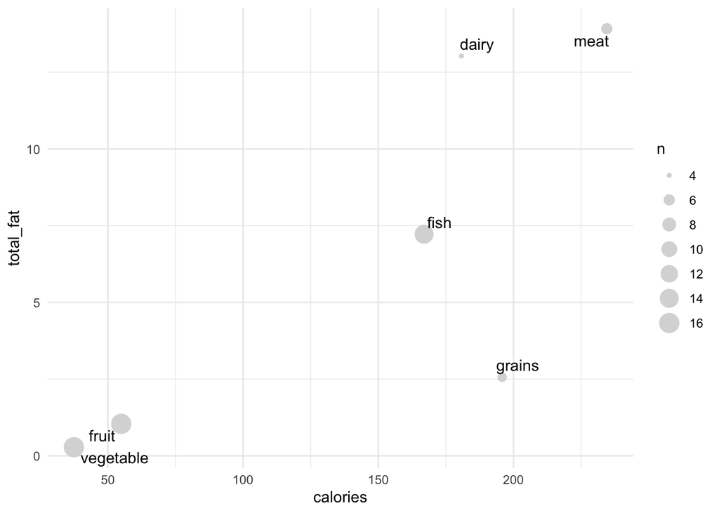

```r
food |>
  group_by(food_group) |>
  summarize(
    calories = mean(calories), total_fat = mean(total_fat), n = n()
  ) |>
  ggplot(aes(calories, total_fat)) +
    geom_point(aes(size = n), color = "grey85") +
    geom_text_repel(aes(label = food_group))
```

If this seems complex, don’t worry! We are just putting together elements that we have already covered, but it takes some practice before it becomes natural.

If we want to create a bar plot, where the heights of the bars as given by a column in the data set, we can use the `geom_col` layer type. For this, assign a categorical variable to the `y`-aesthetic and the count variable to the `x`-aesthetic (or vice-versa). For example, here is a bar plot showing the number of items in each food group:

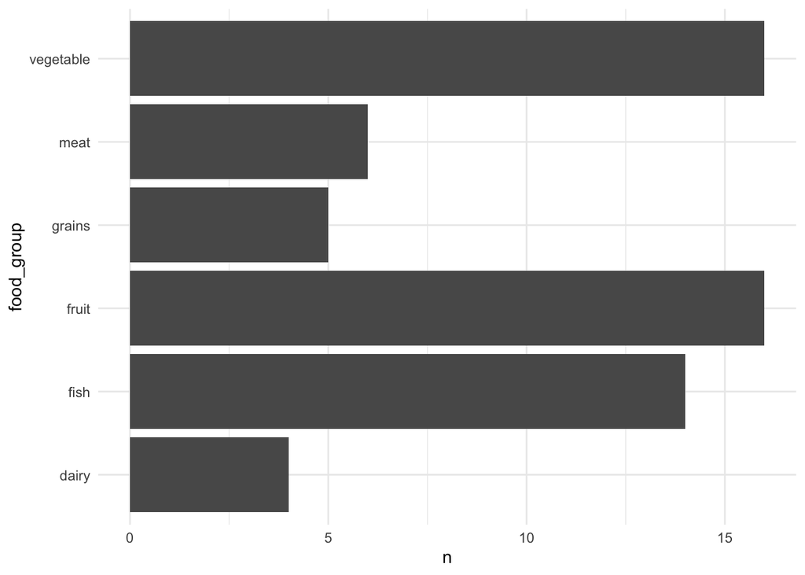

```r
food |>
  group_by(food_group) |>
  summarize(n = n()) |>
  ggplot(aes(n, food_group)) +
    geom_col()
```

There are two specific things to keep in mind with the `geom_col` layer. First, there are two color-related `aes` categories: the border of the bars (`color`) and the color used to shade the inside of the bars (`fill`). We can change these exactly as we did with the single color value used with scatter plots.

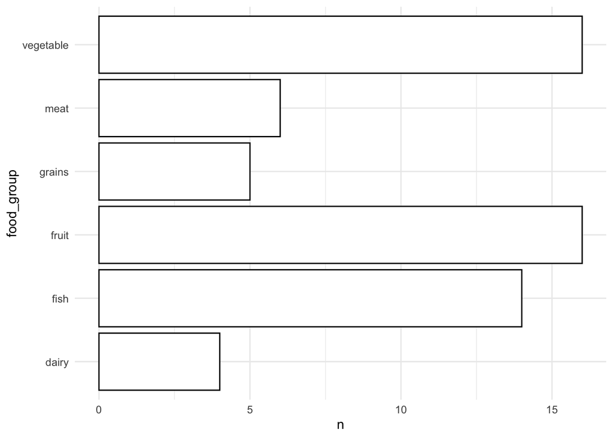

```r
food |>
  group_by(food_group) |>
  summarize(n = n()) |>
  ggplot(aes(n, food_group)) +
    geom_col(color = "black", fill = "white")
```

I find that using a white fill color and a black border is often a good-looking starting point. Also, you will notice that making the bars horizontal will make it easier to read the category names when there are a larger number of categories.

## Multiple groups

As mentioned above, it is possible to group a data set by multiple variables. To do this, we can provide additional variables to the `group_by` function separated by commas. For example, we could group the food data set into food group and color, and summarize each combination of the two:

```r
food |>
  group_by(food_group, color) |>
  summarize(n = n(), calories = mean(calories))
```

```
## # A tibble: 21 × 4
## # Groups:   food_group [6]
##    food_group color      n calories
##    <chr>      <chr>  <int>    <dbl>
##  1 dairy      white      3    124.
##  2 dairy      yellow     1    350
##  3 fish       pink       2    158.
##  4 fish       red        3    112.
##  5 fish       white      9    187.
##  6 fruit      green      4     77.2
##  7 fruit      orange     3     44.7
##  8 fruit      pink       2     35.5
##  9 fruit      purple     2     57.5
## 10 fruit      red        2     42
## # ℹ 11 more rows
```

Notice that now there is one row for each combination of the two groups. However, there is no row for combinations that do not exist. So, there is no row for pink dairy products nor for white fruit.

## Homework Questions

Let’s now take all of the rows from the entire `hans` dataset:

```
## # A tibble: 1,704 × 6
##    country     continent  year life_exp   gdp      pop
##    <chr>       <chr>     <dbl>    <dbl> <dbl>    <dbl>
##  1 Afghanistan Asia       1952     28.8  779.  8425333
##  2 Afghanistan Asia       1957     30.3  821.  9240934
##  3 Afghanistan Asia       1962     32.0  853. 10267083
##  4 Afghanistan Asia       1967     34.0  836. 11537966
##  5 Afghanistan Asia       1972     36.1  740. 13079460
##  6 Afghanistan Asia       1977     38.4  786. 14880372
##  7 Afghanistan Asia       1982     39.9  978. 12881816
##  8 Afghanistan Asia       1987     40.8  852. 13867957
##  9 Afghanistan Asia       1992     41.7  649. 16317921
## 10 Afghanistan Asia       1997     41.8  635. 22227415
## # ℹ 1,694 more rows
```

For each of the following five questions, write the R code that would produce the desired data set:

1. Compute the average life expectancy from the year 2007.
2. Compute the average gdp from the year 2007.
3. Compute the average life expectancy of each continent in the year 2002.
4. Compute the total number of people living in each continent in the year 1957. Note that R has the function `sum()` that might be helpful here.
5. Compute the total number of countries in each continent.

We will talk about these questions together in class.